# Replicating Red, Rank and Romance: the ‘red effect’ revisited

*N* removed NAs: 3

*N* removed typo: 1

*N* removed <18: 22

*N* total clean: 124

| Group | *N* | *M*<sub>age</sub> | *M*<sub>rating</sub> |
| --- | --- | --- | --- |
| Control | 62 | 20.9 | 5.60 |
| Experim | 62 | 20.7 | 6.06 |

**Main analysis results**

*t*(122) = -3.17, *p* = .002

[interactive chart not shown]

[figure not shown]

[interactive chart not shown]

# Replicating Red, Rank and Romance: the ‘red effect’ revisited

Analysing Data, Spring 2020

# Methods

## Participants

*Table 1* Participant Count and Mean Age by Condition

| Condition | Count | *M*<sub>age</sub> | *SD*<sub>age</sub> |
| --- | --- | --- | --- |
| Control | 62 | 20.9 | 1.99 |
| Experimental | 62 | 20.7 | 2.25 |

## Design

This study is a replication of a 2010 study conducted by Elliot et al. (2010). The original study examined whether the colour red might have an effect on the level of attractiveness women assign to men (Elliot et al., 2010, p. 402). According to the research hypothesis, the presence of the colour red should increase the perceived attractiveness rating of a man (Elliot et al., 2010, p. 402). The results of the original study seem to suggest that this ‘red effect’, as it has been called, might indeed be taking place. The aim of our study was to see if the results of the original one could be replicated.

To gain a deeper understanding of the effect of the colour red on attractiveness, female participants were randomly allocated to two conditions. In the control condition, participants viewed a photo of a man with a white background. Those in the experimental condition viewed the same photo with a red background. In the analysis, this variable was operationalised as a factor with two levels - control or experimental.

To assess how attractive the man seemed to the female participants, they were given 5 seconds to look at the photo. Afterward, each participant gave a rating from a 9-point scale on three items: “How attractive do you think this person is?” “How pleasant is this person to look at?” and “If I were to meet the person in this picture face to face, I would think he is attractive.” (Elliot et al., 2010, p. 403). The scale ranged from 1 to 9, with higher ratings corresponding to higher levels of perceived attractiveness. This variable was thus operationalised as a numeric rating with a set range of 1 to 9. The scores of each participant on all 3 items were averaged as a composite score which was used for statistical analysis.

This study predicts that women viewing the photo with a red background will tend to assign higher ratings on the 1-9 scale corresponding to the 3 items, than women who view the same photo with a white background.

The collected data was analysed using an independent-samples *t*-test, which examined the effect of experimental condition on reported ratings of attractiveness.

# Results

To perform analysis of the data, we firstly needed to produce one score per participant that would capture their rating. The 3 ratings from each participant were averaged to form a composite score.

After composite scores were calculated, Generally, participants in the experimental condition rated the man as more attractive than participants in the control condition. The mean composite score of perceived attractiveness for participants in the control group was *M*<sub>control_composite</sub> = 5.6, *SD*<sub>control_composite</sub> = 0.88. The mean composite score of perceived attractiveness for participants in the experimental group was *M*<sub>experimental_composite</sub> = 6.06, *SD*<sub>experimental_composite</sub> = 0.74.

Table 2 shows these composite scores for each experimental group along with the number of participants in these groups.

*Table 2* Mean Composite Score by Condition

| Condition | Count | *M*<sub>composite</sub> | *SD*<sub>composite</sub> |
| --- | --- | --- | --- |
| Control | 62 | 5.60 | 0.88 |
| Experimental | 62 | 6.06 | 0.74 |

Table 3 shows mean scores of attractiveness ratings on all 3 items divided by Condition.

*Table 3* Mean ratings and standard deviations on the 3 items by Condition

| Condition | *M*<sub>Item1</sub> | *SD*<sub>Item1</sub> | *M*<sub>Item2</sub> | *SD*<sub>Item2</sub> | *M*<sub>Item3</sub> | *SD*<sub>Item3</sub> |
| --- | --- | --- | --- | --- | --- | --- |
| Control | 5.77 | 1.58 | 5.76 | 1.52 | 5.27 | 1.28 |
| Experimental | 6.00 | 1.20 | 6.16 | 1.26 | 6.03 | 1.39 |

These results show that the mean perceived attractiveness reported by women in the experimental condition was higher than that reported by women in the control condition. The difference between these mean composite scores was *M*<sub>diff</sub> = -0.46. Using a linear model to compare the differences in means will also produce the same value.

These mean composite scores were also reported in an independent-samples *t*-test. The difference in means was significant (*M*<sub>diff</sub> = -0.46, 95% CI [-0.75, -0.17], *t* (122) = -3.17, *p* = 0.002).

For our data, the probability of obtaining a value of t as big as 3.17 is small. To be specific, the probability p of this occuring is .001917. Rounded up, p = .002. In the original study, the significance level was set to be p < .05 (Elliot et al., 2010, p. 403). Since our probability p is smaller than the set significance level, it is unlikely that our two sample means come from the same population. We can therefore reject the null hypothesis and accept the alternative, concluding that the data comes from different populations. In this case, the two populations are “people who saw a photo with a red frame” and “people who saw a photo with a white frame”.

The result of our analysis suggests that whether a participant perceived the colour red or the colour white in connection with another individual influenced their attractiveness rating of that individual.

Figure 1 shows the difference between the collected sample means in the two experimental groups, calculated from the composite score of each participant.

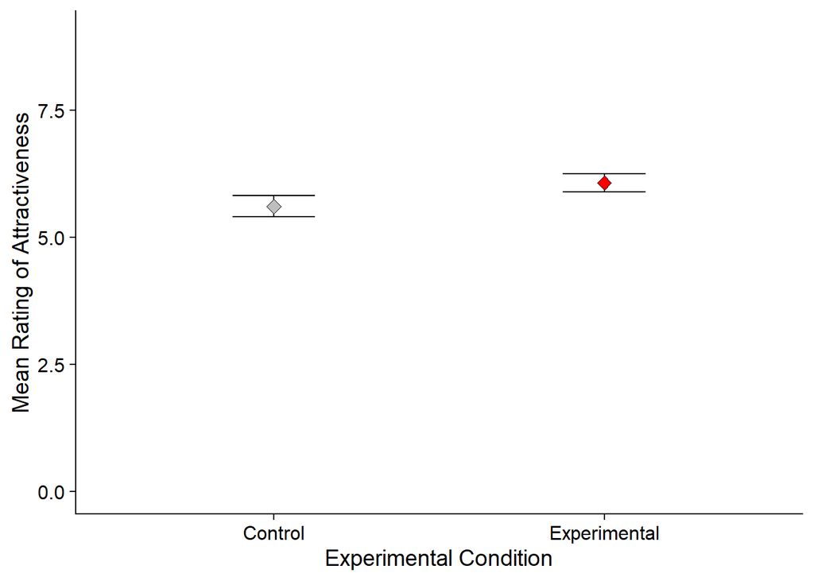

*Figure 1* Mean rating of perceived attractiveness by Condition

# Discussion

The results of the experiment conducted in the present research provide support for the idea that the presence of the colour red positively affects the perceived attractiveness of an individual. The goal of this replication was to see if the Red, Rank and Romance study by Elliot et al. (2010) could be replicated and what the nature of the results would be. As could be seen from the Results section, our data supports the findings published by Elliot et al., thus offering further evidence for the red effect hypothesis.

Results like ours are largely explained by the Colour-in-context theory proposed by Elliot and Maier (2012). This theory is based around social learning and its basic premise is that responses to some colours are a result of the repeated pairing between a colour and certain concepts or emotional experiences (Elliot & Maier, 2012, p. 68). However, Elliot and Maier also allow for a biological predisposition controlling certain responses, which are then further shaped by social influences (2012, p. 68). In short, according to the theory, our social context, coupled with biologically coded processes, influence the meaning or intentions we assign to certain colours (Elliot & Maier, 2012, p. 68).

The present study is not the only one that provides support for the red effect and the Colour-in-context theory. Of special interest is a 2013 study conducted in a remote community based in Burkina Faso (Elliot et al., 2013). The community has historically associated the studied colour with negative experiences (Elliot et al., 2013, p. 166). However, the researchers still found evidence, in the form of attractiveness ratings in conjunction with red, that suggests that the ‘red effect’ is universal in nature, independent of culture-specific associations (Elliot et al., 2013, p. 167). Another study by Guéguen et al. reported a significant effect of red on attractiveness ratings, as compared to blue and green, in a between-subjects design (2012, p. 262). Since the experiments made use of more colours than the present research, it may have more external validity. Additionally, the researchers found that women wearing red were seen to have more sexual intent than those wearing other colours (Guéguen, 2012, p. 263).

However, there is also a number of studies that report a lack of evidence for the effect of red on attractiveness ratings. Peperkoorn et al. conducted 3 separate experiments, similar to the present research in design, investigating the effect of red clothing on ratings of women’s attractiveness (2016). The study did not find a significant effect of the colour, comparing it with both white and black in a between-subjects design to increase external validity (Peperkoorn et al., 2016, p. 9). Results like these call into question whether the red effect, and, more generally, whether the effect of colour on how we perceive others, actually exists.

A different study by Roberts et al. concluded that while an effect of colour on perceived attractiveness is in fact plausible, their findings do not offer supporting evidence for the claim that red in particular is the source of higher attractiveness ratings (2010, p. 359). In several of their experiments, people wearing black clothing were rated as more attractive than those wearing red, suggesting that the red effect might not be universal after all, contrary to what Elliot et al. proposed (2013). The red effect seems to be especially low since Robert et al.’s study made use of a within-subjects design. Their participants had to consider a photo of the same person in different coloured clothing and determine which seems to be the most attractive, giving them more choice than most other studies (Roberts et al., 2010, p. 359).

Whilst our analysis suggests that the presence of red did indeed affect the attractiveness ratings assigned to the man in the photo, the study is not without its limits. One of the main shortcomings of this study is that it only makes use of two colour variables – red and white. It is thus unclear how red would compare to different colour stimuli. However, the design of the present research also allows for a certain degree of confidence in the results. The 3-item rating scale provides a reliable score of attractiveness when the three scores are averaged, as it targets several aspects of attractiveness. Taking this into account, I would argue that the existence of the red effect is possible, but it needs to be studied further in order to form a fuller picture.

Specifically, in order to increase external validity, future studies should include more colours in their design to see how red compares to them in attractiveness ratings. This step is necessary since people usually wear a wide variety of colours in settings outside of the laboratory. A within-subjects design using several colours, inspired by the one Roberts et al. used (2010), might tell us more about how red is interpreted in the presence of other colour variables.

Furthermore, the majority of previously published studies test the red effect on individuals who were pre-rated as moderately attractive in independent tests (Elliot et al., 2010; Elliot & Niesta, 2008; Guéguen, 2012), or fashion models, whose pictures are widely available online (Peperkoorn et al., 2016). To study the full extent of the red effect, experiments need to use pictures of individuals rated both below and above average on attractiveness. Pazda and Greitemeyer also propose this change in experimental design (2015, p. 540). Further, they also propose a manipulation in the specific tone or hue of the colour used for experimental purposes (Pazda & Greitemeyer, 2015, p. 540). This would allow researchers to determine whether a specific type of red has a stronger or weaker effect on attractiveness ratings. They could compare darker reds and brighter reds or reds with orange and pink undertones.

The present study provides evidence for the support of the red effect hypothesis. The results indicate that on average red contributed to higher attractiveness ratings than white. The ‘red effect’ is undoubtedly an interesting phenomenon worth studying in more detail. Future studies should especially focus on including more colours into the comparison as well as look into how different tones of red perform in the experiment. Another possible area of study is the effect the colour could have on the attractiveness rating of individuals pre-rated as unattractive or highly attractive.

# References

Elliot, A. J., & Maier, M. A. (2012). Color-in-Context Theory. In Advances in Experimental Social Psychology (Vol. 45, pp. 61–125). Elsevier. https://doi.org/10.1016/B978-0-12-394286-9.00002-0 (3), 399.

Elliot, A. J., & Niesta, D. (2008). Romantic red: Red enhances men’s attraction to women. Journal of Personality and Social Psychology, 95(5), 1150–1164. https://doi.org/10.1037/0022-3514.95.5.1150 (3), 399.

Elliot, A. J., Niesta Kayser, D., Greitemeyer, T., Lichtenfeld, S., Gramzow, R. H., Maier, M. A., & Liu, H. (2010). Red, rank, and romance in women viewing men. Journal of Experimental Psychology: General, 139(3), 399–417. https://doi.org/10.1037/a0019689 (3), 399.

enhances women’s attractiveness to men: First evidence suggesting universality. Journal of Experimental Social Psychology, 49(1), 165–168. https://doi.org/10.1016/j.jesp.2012.07.017 (3), 399.

Guéguen, N. (2012). Color and Women Attractiveness: When Red Clothed Women Are Perceived to Have More Intense Sexual Intent. The Journal of Social Psychology, 152(3), 261–265. https://doi.org/10.1080/00224545.2011.605398 (3), 399.

Pazda, A. D., & Greitemeyer, T. (2015). Color in romantic contexts in humans. In A. J. Elliot, M. D. Fairchild, & A. Franklin (Eds.), Handbook of Color Psychology (pp. 531–545). Cambridge University Press. https://doi.org/10.1017/CBO9781107337930.026 (3), 399.

Peperkoorn, L. S., Roberts, S. C., & Pollet, T. V. (2016). Revisiting the Red Effect on Attractiveness and Sexual Receptivity: No Effect of the Color Red on Human Mate Preferences. Evolutionary Psychology, 14(4), 147470491667384. https://doi.org/10.1177/1474704916673841 (3), 399.

Roberts, S. C., Owen, R. C., & Havlicek, J. (2010). Distinguishing between Perceiver and Wearer Effects in Clothing Color-Associated Attributions. Evolutionary Psychology, 8(3), 147470491000800. https://doi.org/10.1177/147470491000800304 (3), 399.